# index.Rmd

STATS 220 Semester One 2023

Matthew Sum

2023-04-19

## Introduction

| song_name | artist | album | album_price | song_price | duration_ms | genre | dateReleased | duration_min | album_name_length | song_name_length |
| --- | --- | --- | --- | --- | --- | --- | --- | --- | --- | --- |
| Party | Clint Mansell & Kronos Quartet | Requiem for a Dream (Soundtrack from the Motion Picture) | 9.99 | 0.99 | 28800 | Pop | 2000-10-03 12:00:00 | 0.480000 | 56 | 5 |
| The Summoning | LINKIN PARK | The Hunting Party | 10.99 | -1.00 | 60440 | Hard Rock | 2014-06-13 07:00:00 | 1.007333 | 17 | 13 |
| Party | Dr. Acula | Below Me | 9.99 | 0.99 | 64840 | Rock | 2008-07-22 12:00:00 | 1.080667 | 8 | 5 |
| Let’s Have a Tea Party | The Countdown Kids | 150 Fun Songs for Kids | 9.99 | 0.99 | 70827 | Children’s Music | 2004-04-20 12:00:00 | 1.180450 | 22 | 22 |
| Party | En Vogue | Born to Sing | 9.99 | 1.29 | 70947 | R&B/Soul | 1990-04-03 07:00:00 | 1.182450 | 12 | 5 |
| Dance Party | Sleeping With Sirens | With Ears to See and Eyes to Hear | 9.99 | 1.29 | 92881 | Hard Rock | 2010-03-22 12:00:00 | 1.548017 | 33 | 11 |
| The Prince of Parties | Flight of the Conchords | Flight of the Conchords | 9.99 | 0.99 | 108467 | Alternative | 2008-04-21 07:00:00 | 1.807783 | 23 | 21 |
| Party | The Original Broadway Cast of “Million Dollar Quartet” | Million Dollar Quartet (Original Broadway Cast Recording) | 9.99 | 0.99 | 114307 | Soundtrack | 2010-09-28 12:00:00 | 1.905117 | 57 | 5 |
| Sports - (Chicago Bulls Theme) | Bobby Morganstein | The Complete Grand Entrance Party, Vol. 6 | 9.99 | 0.99 | 125173 | Soundtrack | 1993-01-01 12:00:00 | 2.086217 | 41 | 30 |
| Nobody Really Cares If You Don’t Go to the Party | Courtney Barnett | Sometimes I Sit and Think, and Sometimes I Just Sit | 9.99 | 0.69 | 166080 | Alternative | 2015-03-20 07:00:00 | 2.768000 | 51 | 48 |
| Blue Light | Bloc Party | Silent Alarm | 9.99 | 1.29 | 166227 | Rock | 2005-01-01 12:00:00 | 2.770450 | 12 | 10 |
| Bap U | Party Favor | Bap U - Single | 1.29 | 1.29 | 168207 | Dance | 2014-10-07 12:00:00 | 2.803450 | 14 | 5 |
| Peaches | The Presidents of the United States of America | The Presidents of the United States of America (10th Anniversary Edition) | 9.99 | 0.99 | 171693 | Alternative | 1995-03-01 08:00:00 | 2.861550 | 73 | 7 |
| Love Addict | Family Force 5 | Business Up Front / Party In the Back | 9.99 | 1.29 | 172840 | Rock | 2006-02-14 12:00:00 | 2.880667 | 37 | 11 |
| Party On Fifth Ave. | Mac Miller | Blue Slide Park | 9.99 | 1.29 | 173516 | Hip-Hop/Rap | 2011-10-28 07:00:00 | 2.891933 | 15 | 19 |
| Party | Love Arcade | Love Arcade | 9.99 | 0.99 | 174547 | Alternative | 2006-08-08 12:00:00 | 2.909117 | 11 | 5 |
| Party In the CIA (Parody of “Party In the U.S.A.” by Miley Cyrus) | “Weird Al” Yankovic | Alpocalypse (Deluxe Version) | 13.99 | 1.99 | 176617 | Comedy | 2011-06-27 07:00:00 | 2.943617 | 28 | 65 |
| House Party (Andrew W.K. Remix) [Bonus Track] | 3OH!3 | Streets of Gold (Deluxe Version) | 12.99 | 1.29 | 177899 | Pop | 2010-06-29 07:00:00 | 2.964983 | 32 | 45 |
| How She Rolls | Chase Rice | Ignite the Night (Party Edition) | 5.99 | 1.29 | 179076 | Country | 2013-04-03 07:00:00 | 2.984600 | 32 | 13 |
| Party | Jonn Hart | Heart 2 Hart 2 (Deluxe Edition) | 9.99 | 1.29 | 179836 | Hip-Hop/Rap | 2014-07-24 12:00:00 | 2.997267 | 31 | 5 |

Nested JSON can be advantageous because it allows for a hierarchical organisation of data, which can represent the relationships between different features and attributes of a song or album. I.e. all the values of a specific row is grouped together into one nest, making it easier to read and store the data. An example of Nested JSON for a specific attribute of a song is the album the song belongs to, whether it was released as a single or as part of an album. Nested JSON can easily present the information needed, with additional details such as genre, price, album track number, and more. This allows for a more detailed representation of the song and album, which can be used for more complex analysis or filtering of the data.

## Key features of my playlist

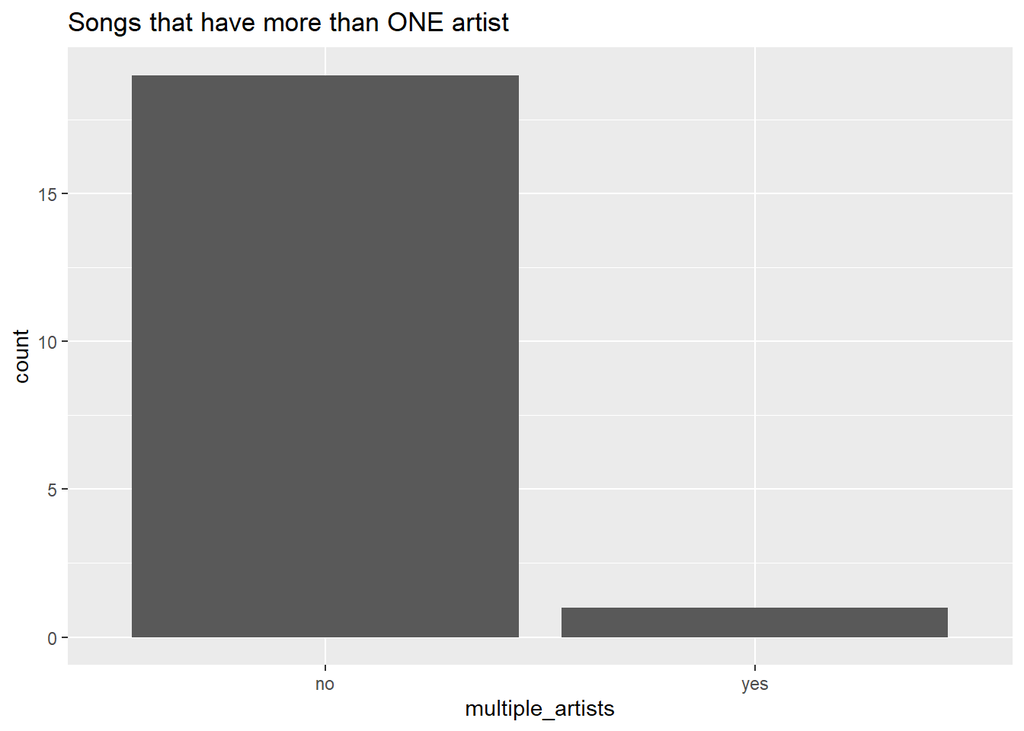

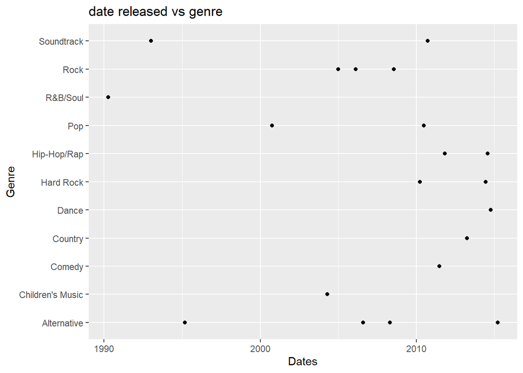

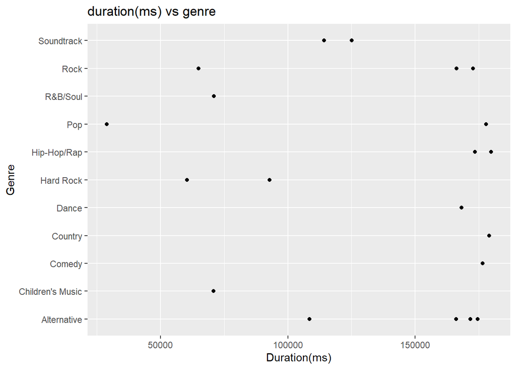

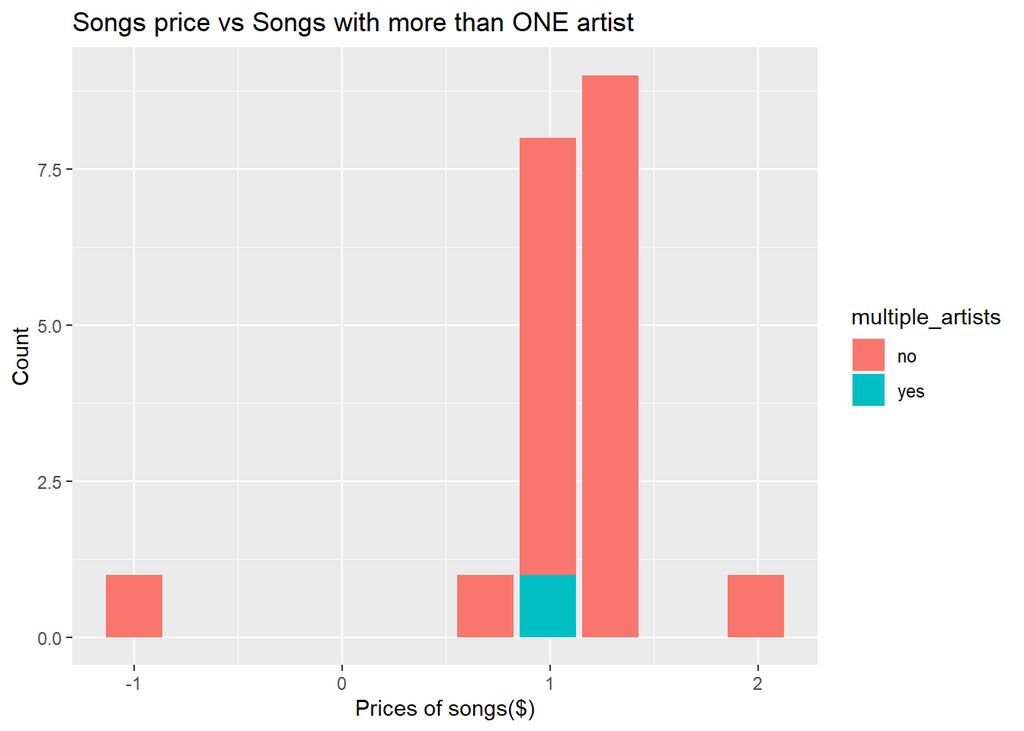

There are 20 songs in the playlist.

The total duration of my playlist is 44.0536667 minutes.

The average price of songs in my playlist is 1.0605 dollars.

## SQL examples

```
SELECT duration_ms, COUNT(*)
FROM tbl_songs
GROUP BY duration_ms;

SELECT DISTINCT artist
FROM tbl_songs
LIMIT 20;
```

The first example is similar to the data manipulation used to create my data frame as I rearranged my initial_playlist with duration_ms in my final playlist (my_playlist). The second example is similar to the data manipulation used to create my data frame as I only included unique artists in my final playlist. My final playlist also only had 20 songs, therefore, in the SQL code I set the limit to 20.

## Learning reflection

One important thing I learned from module 3 is how to use SQL queries. This module taught us how to execute tidyverse code in SQL, which I found to be a useful skillset. In my project, I demonstrated creativity by incorporating graphics (bar charts) from previous assignments. Instead of creating a basic playlist that could have duplicated songs, I went beyond and included only unique artists in my final playlist of 20 songs. This allowed for more variability in the data and graphics when exploring the playlist data since there were no repeat artists or songs. I am interested in further exploring database tables because I believe they are practical and useful. The use of primary/foreign keys makes storing data efficient and simple, and the linking properties of primary keys are fascinating. As someone who enjoys coding and has experience with different coding programs, I find SQL to be a unique type of coding software that differs from basic coding programs like Python or Java. This makes it extremely intriguing to me, and I am curious to learn more about it.

## Appendix

```r
# Loading packages
library(tidyverse)
library(jsonlite)

# creating initial playlist
query <- "https://itunes.apple.com/search?term=party&media=music&limit=200&genre=Hip+Hop"
response <- fromJSON(query)
initial_playlist <- response$results

# Selecting variables
initial_playlist <- initial_playlist %>%
  select(trackName, artistName, collectionName, collectionPrice, trackPrice, trackTimeMillis, primaryGenreName, releaseDate) %>%
  rename(song_name = trackName,
         artist = artistName,
         album = collectionName,
         album_price = collectionPrice,
         song_price = trackPrice,
         duration_ms = trackTimeMillis,
         genre = primaryGenreName,
         dateReleased = releaseDate)

# Arranging data frame based on duration
initial_playlist <- initial_playlist %>%
  arrange(duration_ms)

# Using mutate to create 3 New Variables
my_playlist <- initial_playlist %>%
  mutate(duration_min = duration_ms/60000,
         album_name_length = nchar(album),
         song_name_length = nchar(song_name))

# Using filter to select only 20 songs
my_playlist <-  filter(my_playlist, !duplicated(artist)) %>%
  slice(1:20)

# Saving my_playlist as a CSV file
write_csv(my_playlist, "my_playlist.csv")

# Summary values
personal_songs <- my_playlist %>%
  mutate(personal_name = ifelse(str_detect(str_to_lower(song_name),
                                           "you|me|they|he|she|we|us"),
                                "yes",
                                "no"))
personal_songs %>%
  group_by(personal_name) %>%
  summarise(num_songs = n())

# Creating a bar chart
artist_data <- my_playlist %>%
  mutate(num_artists = str_count(artist, "&") + 1) %>%
  mutate(multiple_artists = ifelse(num_artists >= 2, "yes", "no"))
artist_data %>%
  ggplot() +
  geom_bar(aes(x = multiple_artists)) +
  labs(title = "Songs that have more than ONE artist")

# Tidyverse vs SQL
"
SELECT duration_ms, COUNT(*)
FROM tbl_songs
GROUP BY duration_ms;

SELECT DISTINCT artist
FROM tbl_songs
LIMIT 20;
"
```

## Redemption

I have included css from the previous assignments which has not been asked in any parts. The css gives my html page some color and *character* to the text. I chose a color that I thought correlates to the party theme of my playlist.

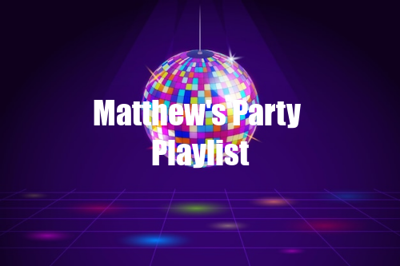

I designed a cover for my playlist using R, demonstrating my ability to create custom images that aren’t just memes. By using the same method of code, I can apply this skill to other projects as well.